# recount quick start guide

L Collado-Torres

25 August 2016

#### Package version: recount 0.99.30

# 1 Quick start to using to *recount*

[figure not shown]

Here is a very quick example of how to download a `RangedSummarizedExperiment` object with the gene counts for a 2 groups project (12 samples) with SRA study id SRP009615 using the *recount* package ([Collado-Torres, Nellore, Kammers, Ellis, et al., 2016](http://biorxiv.org/content/early/2016/08/08/068478)). The `RangedSummarizedExperiment` object is defined in the *SummarizedExperiment* (Morgan, Obenchain, Hester, and Pagès, 2016) package and can be used for differential expression analysis with different packages. Here we show how to use *DESeq2* ([Love, Huber, and Anders, 2014](http://dx.doi.org/10.1186/s13059-014-0550-8)) to perform the differential expresion analysis.

This quick analysis is explained in more detail later on in this document. Further information about the recount project can be found in the publication [pre-print](http://biorxiv.org/content/early/2016/08/08/068478).

```r
## Load library
library('recount')

## Find a project of interest
project_info <- abstract_search('GSE32465')

## Download the gene-level RangedSummarizedExperiment data
download_study(project_info$project)

## Load the data
load(file.path(project_info$project, 'rse_gene.Rdata'))

## Browse the project at SRA
browse_study(project_info$project)

## View GEO ids
colData(rse_gene)$geo_accession

## Extract the sample characteristics
geochar <- lapply(split(colData(rse_gene), seq_len(nrow(colData(rse_gene)))), geo_characteristics)

## Note that the information for this study is a little inconsistent, so we
## have to fix it.
geochar <- do.call(rbind, lapply(geochar, function(x) {
    if('cells' %in% colnames(x)) {
        colnames(x)[colnames(x) == 'cells'] <- 'cell.line'
        return(x)
    } else {
        return(x)
    }
}))

## We can now define some sample information to use
sample_info <- data.frame(
    run = colData(rse_gene)$run,
    group = ifelse(grepl('uninduced', colData(rse_gene)$title), 'uninduced', 'induced'),
    gene_target = sapply(colData(rse_gene)$title, function(x) { strsplit(strsplit(x,
        'targeting ')[[1]][2], ' gene')[[1]][1] }),
    cell.line = geochar$cell.line
)

## Scale counts by taking into account the total coverage per sample
rse <- scale_counts(rse_gene)

## Add sample information for DE analysis
colData(rse)$group <- sample_info$group
colData(rse)$gene_target <- sample_info$gene_target

## Perform differential expression analysis with DESeq2
library('DESeq2')

## Specify design and switch to DESeq2 format
dds <- DESeqDataSet(rse, ~ gene_target + group)

## Perform DE analysis
dds <- DESeq(dds, test = 'LRT', reduced = ~ gene_target, fitType = 'local')
res <- results(dds)

## Explore results
plotMA(res, main="DESeq2 results for SRP009615")

## Make a report with the results
library('regionReport')
DESeq2Report(dds, res = res, project = 'SRP009615',
    intgroup = c('group', 'gene_target'), outdir = '.',
    output = 'SRP009615-results')
```

The [recount project](https://jhubiostatistics.shinyapps.io/recount/) also hosts the necessary data to perform annotation-agnostic differential expression analyses with *derfinder* ([Collado-Torres, Nellore, Frazee, Wilks, et al., 2016](http://biorxiv.org/content/early/2016/05/07/015370)). An example analysis would like this:

```r
## Define expressed regions for study SRP009615, only for chromosome Y
regions <- expressed_regions('SRP009615', 'chrY', cutoff = 5L,
    maxClusterGap = 3000L)

## Compute coverage matrix for study SRP009615, only for chromosome Y
system.time( coverageMatrix <- coverage_matrix('SRP009615', 'chrY', regions) )

## Round the coverage matrix to integers
covMat <- round(coverageMatrix, 0)

## Get phenotype data for study SRP009615
pheno_url <- download_study(project = project_info$project, type = 'phenotype',
    download = FALSE)
pheno <- read.table(pheno_url, header = TRUE, stringsAsFactors = FALSE)

## We can sort the table to make sure everything is in the correct order
pheno <- pheno[match(colnames(coverageMatrix), pheno$run), ]

## Complete the phenotype table with the data we got from GEO
m <- match(pheno$run, sample_info$run)
pheno <- cbind(pheno, sample_info[m, 2:3])

## Build a DESeqDataSet
dds_ers <- DESeqDataSetFromMatrix(countData = covMat, colData = pheno,
    design =  ~ gene_target + group)

## Perform differential expression analysis with DESeq2 at the ER-level
dds_ers <- DESeq(dds_ers, test = 'LRT', reduced = ~ gene_target,
    fitType = 'local')
res_ers <- results(dds_ers)

## Explore results
plotMA(res_ers, main="DESeq2 results for SRP009615 (ER-level, chrY)")

## Create a more extensive exploratory report
DESeq2Report(dds_ers, res = res_ers,
    project = 'SRP009615 (ER-level, chrY)',
    intgroup = c('group', 'gene_target'), outdir = '.',
    output = 'SRP009615-results-ER-level-chrY')
```

# 2 Introduction

*recount* is an R package that provides an interface to the [recount project website](https://jhubiostatistics.shinyapps.io/recount/). This package allows you to download the files from the recount project and has helper functions for getting you started with differential expression analyses. This vignette will walk you through an example.

# 3 Sample DE analysis

This is a brief overview of what you can do with *recount*. In this particular example we will download data from the SRP009615 study which sequenced 12 samples as described in the previous link.

If you don’t have *recount* installed, please do so with:

```r
## try http:// if https:// URLs are not supported
source("https://bioconductor.org/biocLite.R")
biocLite("recount")
```

Next we load the required packages. Loading *recount* will load the required dependencies.

```r
## Load recount R package
library('recount')
```

Lets say that we don’t know the actual SRA accession number for this study but we do know a particular term which will help us identify it. If that’s the case, we can use the `abstract_search()` function to identify the study of interest as shown below.

```r
## Find a project of interest
project_info <- abstract_search('GSE32465')

## Explore info
project_info
```

```
##     number_samples species
## 340             12   human
##                                                                                                                                                                                                                                                                                                          …
## 340 Summary: K562-shX cells are made in an effort to validate TFBS data and ChIP-seq antibodies in Myers lab (GSE32465). K562 cells are transduced with lentiviral vector having Tet-inducible shRNA targeting a transcription factor gene. Cells with stable integration of shRNA constructs are selecte…
##       project
## 340 SRP009615
```

## 3.1 Download data

Now that we have a study that we are interested in, we can download the *RangedSummarizedExperiment* object (see *SummarizedExperiment*) with the data summarized at the gene level. The function `download_study()` helps us do this. If you are interested on how the annotation was defined, check `reproduce_ranges()`.

```r
## Download the gene-level RangedSummarizedExperiment data
download_study(project_info$project)
```

```
## 2016-08-25 15:52:58 downloading file rse_gene.Rdata to SRP009615
```

```r
## Load the data
load(file.path(project_info$project, 'rse_gene.Rdata'))
```

We can explore a bit this *RangedSummarizedExperiment* as shown below.

```r
rse_gene
```

```
## class: RangedSummarizedExperiment
## dim: 23779 12
## metadata(0):
## assays(1): counts
## rownames(23779): 1 10 ... 9994 9997
## rowData names(3): gene_id bp_length symbol
## colnames(12): SRR387777 SRR387778 ... SRR389083 SRR389084
## colData names(21): project sample ... title characteristics
```

```r
## This is the sample phenotype data provided by the recount project
colData(rse_gene)
```

```
## DataFrame with 12 rows and 21 columns
##               project      sample  experiment         run
##           <character> <character> <character> <character>
## SRR387777   SRP009615   SRS281685   SRX110461   SRR387777
## SRR387778   SRP009615   SRS281686   SRX110462   SRR387778
## SRR387779   SRP009615   SRS281687   SRX110463   SRR387779
## SRR387780   SRP009615   SRS281688   SRX110464   SRR387780
## SRR389077   SRP009615   SRS282369   SRX111299   SRR389077
## ...               ...         ...         ...         ...
## SRR389080   SRP009615   SRS282372   SRX111302   SRR389080
## SRR389081   SRP009615   SRS282373   SRX111303   SRR389081
## SRR389082   SRP009615   SRS282374   SRX111304   SRR389082
## SRR389083   SRP009615   SRS282375   SRX111305   SRR389083
## SRR389084   SRP009615   SRS282376   SRX111306   SRR389084
##           read_count_as_reported_by_sra reads_downloaded
##                               <integer>        <integer>
## SRR387777                      30631853         30631853
## SRR387778                      37001306         37001306
## SRR387779                      40552001         40552001
## SRR387780                      32466352         32466352
## SRR389077                      27819603         27819603
## ...                                 ...              ...
## SRR389080                      34856203         34856203
## SRR389081                      23351679         23351679
## SRR389082                      18144828         18144828
## SRR389083                      24417368         24417368
## SRR389084                      23060084         23060084
##           proportion_of_reads_reported_by_sra_downloaded paired_end
##                                                <numeric>  <logical>
## SRR387777                                              1      FALSE
## SRR387778                                              1      FALSE
## SRR387779                                              1      FALSE
## SRR387780                                              1      FALSE
## SRR389077                                              1      FALSE
## ...                                                  ...        ...
## SRR389080                                              1      FALSE
## SRR389081                                              1      FALSE
## SRR389082                                              1      FALSE
## SRR389083                                              1      FALSE
## SRR389084                                              1      FALSE
```

[output cut: 63 more lines]

```
## SRR389083  K562 cells with shRNA targeting ATF3 gene cultured with no doxycycline (uninduced - UI), rep2.
## SRR389084 K562 cells with shRNA targeting ATF3 gene cultured with doxycycline for 24 hours (24 hr), rep2.
##                                                                                               characteristics
##                                                                                               <CharacterList>
## SRR387777                                               cells: K562,shRNA expression: no,treatment: Puromycin
## SRR387778                  cells: K562,shRNA expression: yes, targeting SRF,treatment: Puromycin, doxycycline
## SRR387779                                               cells: K562,shRNA expression: no,treatment: Puromycin
## SRR387780                   cells: K562,shRNA expression: yes targeting SRF,treatment: Puromycin, doxycycline
## SRR389077                          cell line: K562,shRNA expression: no shRNA expression,treatment: Puromycin
## ...                                                                                                       ...
## SRR389080 cell line: K562,shRNA expression: expressing shRNA targeting EGR1,treatment: Puromycin, doxycycline
## SRR389081                          cell line: K562,shRNA expression: no shRNA expression,treatment: Puromycin
## SRR389082 cell line: K562,shRNA expression: expressing shRNA targeting ATF3,treatment: Puromycin, doxycycline
## SRR389083                          cell line: K562,shRNA expression: no shRNA expression,treatment: Puromycin
## SRR389084 cell line: K562,shRNA expression: expressing shRNA targeting ATF3,treatment: Puromycin, doxycycline
```

```r
## At the gene level, the row data includes the gene ENTREZ ids, the gene
## symbols and the sum of the reduced exons widths, which can be used for
## taking into account the gene length.
rowData(rse_gene)
```

```
## DataFrame with 23779 rows and 3 columns
##           gene_id bp_length      symbol
##       <character> <integer> <character>
## 1               1      4027        A1BG
## 2              10      1317        NAT2
## 3             100      1532         ADA
## 4            1000      4473        CDH2
## 5       100008589      5071     RNA28S5
## ...           ...       ...         ...
## 23775        9991      8234       PTBP3
## 23776        9992       803       KCNE2
## 23777        9993      4882       DGCR2
## 23778        9994      6763    CASP8AP2
## 23779        9997      1393        SCO2
```

```r
## At the exon level, you can get the gene ENTREZ ids from the names of:
# rowRanges(rse_exon)
```

## 3.2 Finding phenotype information

Once we have identified the study of interest, we can use the `browse_study()` function to browse the study at the SRA website.

```r
## Browse the project at SRA
browse_study(project_info$project)
```

The SRA website includes an *Experiments* link which further describes each of the samples. From the information available for [SRP009615 at NCBI](http://www.ncbi.nlm.nih.gov/sra/?term=SRP009615) we have some further sample information that we can save for use in our differential expression analysis. We can get some of this information from [GEO](http://www.ncbi.nlm.nih.gov/geo/). The function `find_geo()` finds the [GEO](http://www.ncbi.nlm.nih.gov/geo/) accession id for a given SRA run accession id, which we can then use with `geo_info()` and `geo_characteristics()` to parse this information. The `rse_gene` object already has some of this information.

```r
## View GEO ids
colData(rse_gene)$geo_accession
```

```
##  [1] "GSM836270" "GSM836271" "GSM836272" "GSM836273" "GSM847561"
##  [6] "GSM847562" "GSM847563" "GSM847564" "GSM847565" "GSM847566"
## [11] "GSM847567" "GSM847568"
```

```r
## Extract the sample characteristics
geochar <- lapply(split(colData(rse_gene), seq_len(nrow(colData(rse_gene)))), geo_characteristics)

## Note that the information for this study is a little inconsistent, so we
## have to fix it.
geochar <- do.call(rbind, lapply(geochar, function(x) {
    if('cells' %in% colnames(x)) {
        colnames(x)[colnames(x) == 'cells'] <- 'cell.line'
        return(x)
    } else {
        return(x)
    }
}))

## We can now define some sample information to use
sample_info <- data.frame(
    run = colData(rse_gene)$run,
    group = ifelse(grepl('uninduced', colData(rse_gene)$title), 'uninduced', 'induced'),
    gene_target = sapply(colData(rse_gene)$title, function(x) { strsplit(strsplit(x,
        'targeting ')[[1]][2], ' gene')[[1]][1] }),
    cell.line = geochar$cell.line
)
```

## 3.3 DE analysis

The [recount project](https://jhubiostatistics.shinyapps.io/recount/) records the sum of the base level coverage for each gene (or exon). These raw counts have to be scaled and there are several ways in which you can choose to do so. The function `scale_counts()` helps you scale them in a way that is tailored to [Rail-RNA](http://rail.bio) output.

```r
## Scale counts by taking into account the total coverage per sample
rse <- scale_counts(rse_gene)
```

We are almost ready to perform our differential expression analysis. Lets just add the information we recovered [GEO](http://www.ncbi.nlm.nih.gov/geo/) about these samples.

```r
## Add sample information for DE analysis
colData(rse)$group <- sample_info$group
colData(rse)$gene_target <- sample_info$gene_target
```

Now that the *RangedSummarizedExperiment* is complete, we can use *DESeq2* or another package to perform the differential expression test. Note that you can use *DEFormats* for switching between formats if you want to use another package, like *edgeR*.

In this particular analysis, we’ll test whether there is a group difference adjusting for the gene target.

```r
## Perform differential expression analysis with DESeq2
library('DESeq2')

## Specify design and switch to DESeq2 format
dds <- DESeqDataSet(rse, ~ gene_target + group)
## Perform DE analysis
dds <- DESeq(dds, test = 'LRT', reduced = ~ gene_target, fitType = 'local')
res <- results(dds)
```

We can now use functions from *DESeq2* to explore the results. For more details check the *DESeq2* vignette. For example, we can make a MA plot as shown below.

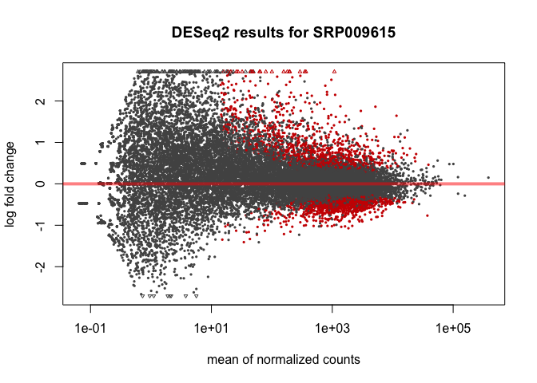

```r
## Explore results
plotMA(res, main="DESeq2 results for SRP009615")
```

## 3.4 Report results

We can also use the *regionReport* package to generate interactive HTML reports exploring the *DESeq2* results (or *edgeR* results if you used that package).

```r
## Make a report with the results
library('regionReport')
report <- DESeq2Report(dds, res = res, project = 'SRP009615',
    intgroup = c('group', 'gene_target'), outdir = '.',
    output = 'SRP009615-results', nBest = 10, nBestFeatures = 2)
```

```
## Writing 9 Bibtex entries ...
```

```
## OK
## Results written to file './SRP009615-results.bib'
```

```
## processing file: SRP009615-results.Rmd
```

```
## output file: SRP009615-results.knit.md
```

```
##
## Output created: SRP009615-results.html
```

## 3.5 Finding gene names

The gene ENTREZ ids are included in several objects in `recount`. With these ids you can find the gene symbols, gene names and other information. The *org.Hs.eg.db* is useful for finding this information and the following code shows how to get the gene names and symbols.

```r
## Load required library
library('org.Hs.eg.db')
## Extract ENTREZ gene ids
entrez <- names(recount_genes)

## Find the gene information we are interested in
gene_info <- select(org.Hs.eg.db, entrez, c('ENTREZID', 'GENENAME', 'SYMBOL'),
    'ENTREZID')
## Explore part of the results
dim(gene_info)
```

```
## [1] 23779     3
```

```r
head(gene_info)
```

```
##    ENTREZID                                              GENENAME   SYMBOL
## 1         1                                alpha-1-B glycoprotein     A1BG
## 2        10 N-acetyltransferase 2 (arylamine N-acetyltransferase)     NAT2
## 3       100                                   adenosine deaminase      ADA
## 4      1000                                            cadherin 2     CDH2
## 5 100008589                                  RNA, 28S ribosomal 5  RNA28S5
## 6 100009613                   ANO1 antisense RNA 2 (head to head) ANO1-AS2
```

# 4 Sample *derfinder* analysis

The [recount project](https://jhubiostatistics.shinyapps.io/recount/) also hosts for each project sample coverage [bigWig files](https://genome.ucsc.edu/goldenpath/help/bigWig.html) created by [Rail-RNA](http://rail.bio) and a mean coverage bigWig file. For the mean coverage bigWig file, all samples were normalized to libraries of 40 million reads, each a 100 base-pairs long. *recount* can be used along with *derfinder* ([Collado-Torres, Nellore, Frazee, Wilks, et al., 2016](http://biorxiv.org/content/early/2016/05/07/015370)) to identify expressed regions from the data. This type of analysis is annotation-agnostic which can be advantageous. The following subsections illustrate this type of analysis.

## 4.1 Define expressed regions

For an annotation-agnostic differential expression analysis, we first need to define the regions of interest. With *recount* we can do so using the `expressed_regions()` function as shown below for the same study we studied earlier.

```r
## Define expressed regions for study SRP009615, only for chromosome Y
regions <- expressed_regions('SRP009615', 'chrY', cutoff = 5L,
    maxClusterGap = 3000L)
```

```
## 2016-08-25 15:54:16 loadCoverage: loading BigWig file http://duffel.rail.bio/recount/SRP009615/bw/mean_SRP009615.bw
```

```
## 2016-08-25 15:54:17 loadCoverage: applying the cutoff to the merged data
```

```
## 2016-08-25 15:54:17 filterData: originally there were 57227415 rows, now there are 57227415 rows. Meaning that 0 percent was filtered.
```

```
## 2016-08-25 15:54:17 findRegions: identifying potential segments
```

```
## 2016-08-25 15:54:17 findRegions: segmenting information
```

```
## 2016-08-25 15:54:17 .getSegmentsRle: segmenting with cutoff(s) 5
```

```
## 2016-08-25 15:54:17 findRegions: identifying candidate regions
```

```
## 2016-08-25 15:54:18 findRegions: identifying region clusters
```

```r
## Briefly explore the resulting regions
regions
```

```
## GRanges object with 808 ranges and 6 metadata columns:
##       seqnames               ranges strand |            value
##          <Rle>            <IRanges>  <Rle> |        <numeric>
##     1     chrY   [2929794, 2929829]      * | 14.7265009482702
##     2     chrY   [2956678, 2956701]      * | 12.8106340567271
##     3     chrY   [2977203, 2977227]      * | 5.34908433914185
##     4     chrY   [2977957, 2977994]      * | 6.46976616508082
##     5     chrY   [2978850, 2978871]      * |  5.7976552139629
##   ...      ...                  ...    ... .              ...
##   804     chrY [26614511, 26614546]      * | 7.28189378314548
##   805     chrY [26614548, 26614553]      * | 5.48768202463786
##   806     chrY [26614779, 26614808]      * | 6.64339276949565
##   807     chrY [26626808, 26626848]      * | 12.6038152648181
##   808     chrY [26626971, 26627028]      * | 14.1673366941255
##                   area indexStart  indexEnd cluster clusterL
##              <numeric>  <integer> <integer>   <Rle>    <Rle>
##     1 530.154034137726    2929794   2929829       1       36
##     2  307.45521736145    2956678   2956701       2       24
##     3 133.727108478546    2977203   2977227       3     2750
##     4 245.851114273071    2977957   2977994       3     2750
##     5 127.548414707184    2978850   2978871       3     2750
##   ...              ...        ...       ...     ...      ...
##   804 262.148176193237   26614511  26614546     224      298
##   805 32.9260921478271   26614548  26614553     224      298
##   806 199.301783084869   26614779  26614808     224      298
##   807 516.756425857544   26626808  26626848     225      221
##   808 821.705528259277   26626971  26627028     225      221
##   -------
##   seqinfo: 1 sequence from an unspecified genome
```

Once the regions have been defined, you can export them into a BED file using *rtracklayer* or other file formats.

## 4.2 Compute coverage matrix

Having defined the expressed regions, we can now compute a coverage matrix for these regions. We can do so using the function `coverage_matrix()` from *recount* as shown below.

```r
## Compute coverage matrix for study SRP009615, only for chromosome Y
system.time( coverageMatrix <- coverage_matrix('SRP009615', 'chrY', regions) )
```

```
## 2016-08-25 15:54:19 railMatrix: processing regions 1 to 808
```

```
## 2016-08-25 15:54:19 railMatrix: processing file http://duffel.rail.bio/recount/SRP009615/bw/SRR387777.bw
```

```
## 2016-08-25 15:54:20 railMatrix: processing file http://duffel.rail.bio/recount/SRP009615/bw/SRR387778.bw
```

```
## 2016-08-25 15:54:22 railMatrix: processing file http://duffel.rail.bio/recount/SRP009615/bw/SRR387779.bw
```

```
## 2016-08-25 15:54:23 railMatrix: processing file http://duffel.rail.bio/recount/SRP009615/bw/SRR387780.bw
```

```
## 2016-08-25 15:54:25 railMatrix: processing file http://duffel.rail.bio/recount/SRP009615/bw/SRR389077.bw
```

```
## 2016-08-25 15:54:26 railMatrix: processing file http://duffel.rail.bio/recount/SRP009615/bw/SRR389078.bw
```

```
## 2016-08-25 15:54:28 railMatrix: processing file http://duffel.rail.bio/recount/SRP009615/bw/SRR389079.bw
```

```
## 2016-08-25 15:54:30 railMatrix: processing file http://duffel.rail.bio/recount/SRP009615/bw/SRR389080.bw
```

```
## 2016-08-25 15:54:31 railMatrix: processing file http://duffel.rail.bio/recount/SRP009615/bw/SRR389081.bw
```

```
## 2016-08-25 15:54:33 railMatrix: processing file http://duffel.rail.bio/recount/SRP009615/bw/SRR389082.bw
```

```
## 2016-08-25 15:54:34 railMatrix: processing file http://duffel.rail.bio/recount/SRP009615/bw/SRR389083.bw
```

```
## 2016-08-25 15:54:36 railMatrix: processing file http://duffel.rail.bio/recount/SRP009615/bw/SRR389084.bw
```

```
##    user  system elapsed
##   5.264   0.525  18.521
```

```r
## Explore the matrix a bit
dim(coverageMatrix)
```

```
## [1] 808  12
```

```r
head(coverageMatrix)
```

```
##   SRR387777 SRR387778 SRR387779 SRR387780 SRR389077 SRR389078  SRR389079
## 1 652.74757  475.9984 951.71899  793.9036    0.0000   0.00000 1177.16960
## 2 516.75849  648.1680  65.84219    0.0000  689.0547 416.16425  151.21744
## 3  97.13506    0.0000 149.64135  186.3624  223.7191  99.08673  302.43488
## 4 186.49931  290.3253 251.39747  447.2696  366.8993 118.90407  325.69910
## 5 159.30149    0.0000   0.00000  245.9983  196.8728 249.69855   51.18129
## 6 330.25919  303.8288 260.37595  216.1803  183.4496 237.80814   65.13982
##   SRR389080 SRR389081 SRR389082 SRR389083 SRR389084
## 1 550.05125  701.0488    0.0000  515.9221  543.2881
## 2  75.63205  112.5772  155.8318  858.2165    0.0000
## 3 168.45320    0.0000    0.0000  124.0197  253.8729
## 4 154.70191  235.3886  389.5795  183.5492    0.0000
## 5 151.26409  112.5772  142.8458  109.1374  111.7041
## 6 206.26922    0.0000  376.5935  267.8826    0.0000
```

The resulting count matrix has one row per region and one column per sample. The counts correspond to the number (or fraction) of reads overlapping the regions. For some differential expression methods, you might have to round this matrix into integers. We’ll use *DESeq2* to identify which expressed regions are differentially expressed.

```r
## Round the coverage matrix to integers
covMat <- round(coverageMatrix, 0)
```

## 4.3 Construct a `DESeqDataSet` object

We first need to get some phenotype information for these samples similar to the first analysis we did. We can get this data using `download_study()`.

```r
## Get phenotype data for study SRP009615
pheno_url <- download_study(project = project_info$project, type = 'phenotype',
    download = FALSE)
pheno <- read.table(pheno_url, header = TRUE, stringsAsFactors = FALSE, sep = '\t')

## We can sort the table to make sure everything is in the correct order
pheno <- pheno[match(colnames(coverageMatrix), pheno$run), ]

## Complete the phenotype table with the data we got from GEO
m <- match(pheno$run, sample_info$run)
pheno <- cbind(pheno, sample_info[m, 2:3])

## Explore the phenotype data a little bit
head(pheno)
```

```
##     project    sample experiment       run read_count_as_reported_by_sra
## 1 SRP009615 SRS281685  SRX110461 SRR387777                      30631853
## 2 SRP009615 SRS281686  SRX110462 SRR387778                      37001306
## 3 SRP009615 SRS281687  SRX110463 SRR387779                      40552001
## 4 SRP009615 SRS281688  SRX110464 SRR387780                      32466352
## 5 SRP009615 SRS282369  SRX111299 SRR389077                      27819603
## 6 SRP009615 SRS282370  SRX111300 SRR389078                      31758658
##   reads_downloaded proportion_of_reads_reported_by_sra_downloaded
## 1         30631853                                              1
## 2         37001306                                              1
## 3         40552001                                              1
## 4         32466352                                              1
## 5         27819603                                              1
## 6         31758658                                              1
##   paired_end sra_misreported_paired_end mapped_read_count        auc
```

[output cut: 48 more lines]

Now that we have the necessary data, we can construct a `DESeqDataSet` object using the function `DESeqDataSetFromMatrix()` from *DESeq2*.

```r
## Build a DESeqDataSet
dds_ers <- DESeqDataSetFromMatrix(countData = covMat, colData = pheno,
    design =  ~ gene_target + group)
```

## 4.4 *DESeq2* analysis

With the `DESeqDataSet` object in place, we can then use the function `DESeq()` from *DESeq2* to perform the differential expression analysis (between groups) as shown below.

```r
## Perform differential expression analysis with DESeq2 at the ER-level
dds_ers <- DESeq(dds_ers, test = 'LRT', reduced = ~ gene_target,
    fitType = 'local')
res_ers <- results(dds_ers)
```

We can then visually explore the results, like we did before.

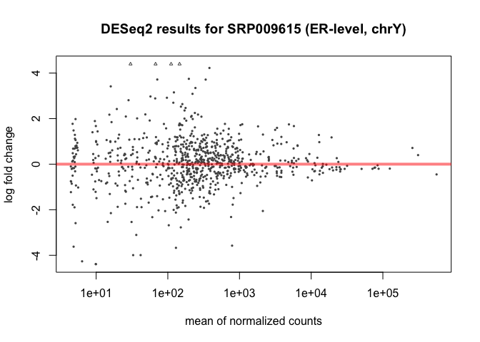

```r
## Explore results
plotMA(res_ers, main="DESeq2 results for SRP009615 (ER-level, chrY)")
```

We can also use *regionReport* to create a more extensive exploratory report.

```r
## Create the report
report2 <- DESeq2Report(dds_ers, res = res_ers,
    project = 'SRP009615 (ER-level, chrY)',
    intgroup = c('group', 'gene_target'), outdir = '.',
    output = 'SRP009615-results-ER-level-chrY')
```

# 5 Snaptron

Our collaborators built *SnaptronUI* to query the [Intropolis](https://github.com/nellore/intropolis) database of the exon-exon junctions found in SRA. *SnaptronUI* allows you to do several types of queries manually and perform analyses. *recount* has the function `snaptron_query()` which uses [Snaptron](https://github.com/ChristopherWilks/snaptron) to check if particular exon-exon junctions are present in *Intropolis*. For example, here we use `snaptron_query()` to get in `R`-friendly format the information for 3 exon-exon junctions using *Intropolis* version 1 which uses hg19 coordinates.

```r
library('GenomicRanges')
junctions <- GRanges(seqnames = 'chr2', IRanges(
    start = c(28971711, 29555082, 29754983),
    end = c(29462418, 29923339, 29917715)))

snaptron_query(junctions)
```

```
## 2016-08-25 15:54:42 querying Snaptron
```

```
## 2016-08-25 15:54:44 processing results
```

```
## 2016-08-25 15:54:44 extracting information
```

```
## GRanges object with 3 ranges and 14 metadata columns:
##       seqnames               ranges strand |     type snaptron_id
##          <Rle>            <IRanges>  <Rle> | <factor>   <integer>
##   [1]     chr2 [28971711, 29462418]      - |    SRA:I    22314441
##   [2]     chr2 [29555082, 29923339]      + |    SRA:I    22328842
##   [3]     chr2 [29754983, 29917715]      - |    SRA:I    22329293
##       annotated  left_motif right_motif  left_annotated right_annotated
##       <logical> <character> <character> <CharacterList> <CharacterList>
##   [1]     FALSE          AT          AC              NA              NA
##   [2]     FALSE          GC          AG              NA              NA
##   [3]      TRUE          GT          AG      ES,UC,RG:1      ES,UC,RG:1
##                  samples read_coverage_by_sample samples_count
##            <IntegerList>           <IntegerList>     <integer>
##   [1]               3481                       1             1
##   [2] 2643,4867,4945,...               1,1,1,...            13
##   [3]         3,5,13,...               1,1,1,...          1625
##       coverage_sum coverage_avg coverage_median source_dataset_id
##          <integer>    <numeric>       <numeric>         <integer>
##   [1]            1        1.000               1                 1
##   [2]           13        1.000               1                 1
##   [3]         5380        3.311               1                 1
##   -------
##   seqinfo: 1 sequence from an unspecified genome; no seqlengths
```

If you use `snaptron_query()` please cite stingray.cs.jhu.edu:8090/snaptron/docs/. *Snaptron* is separate from *recount*. Thank you!

# 6 Basics

## 6.1 Install *recount*

`R` is an open-source statistical environment which can be easily modified to enhance its functionality via packages. *recount* is a `R` package available via the [Bioconductor](http://bioconductor/packages/derfinder) repository for packages. `R` can be installed on any operating system from [CRAN](https://cran.r-project.org/) after which you can install *recount* by using the following commands in your `R` session:

```r
## try http:// if https:// URLs are not supported
source("https://bioconductor.org/biocLite.R")
biocLite("recount")
```

## 6.2 Required knowledge

*recount* is based on many other packages and in particular in those that have implemented the infrastructure needed for dealing with RNA-seq data. That is, packages like *GenomicFeatures* and *rtracklayer* that allow you to import the data. A *recount* user is not expected to deal with those packages directly but will need to be familiar with *SummarizedExperiment* to understand the results *recount* generates. It might also prove to be highly beneficial to check the

- *DESeq2* package for performing differential expression analysis with the *RangedSummarizedExperiment* objects,
- *DEFormats* package for switching the objects to those used by other differential expression packages such as *edgeR*,
- *derfinder* package for performing annotation-agnostic differential expression analysis.

If you are asking yourself the question “Where do I start using Bioconductor?” you might be interested in [this blog post](http://lcolladotor.github.io/2014/10/16/startBioC/#.VkOKbq6rRuU).

## 6.3 Asking for help

As package developers, we try to explain clearly how to use our packages and in which order to use the functions. But `R` and `Bioconductor` have a steep learning curve so it is critical to learn where to ask for help. The blog post quoted above mentions some but we would like to highlight the [Bioconductor support site](https://support.bioconductor.org/) as the main resource for getting help. Other alternatives are available such as creating GitHub issues and tweeting. However, please note that if you want to receive help you should adhere to the [posting guidlines](http://www.bioconductor.org/help/support/posting-guide/). It is particularly critical that you provide a small reproducible example and your session information so package developers can track down the source of the error.

## 6.4 Citing *recount*

We hope that *recount* will be useful for your research. Please use the following information to cite the package and the overall approach. Thank you!

```r
## Citation info
citation('recount')
```

```
##
## Collado-Torres L, Nellore A, Kammers K, Ellis SE, Taub MA, Hansen
## KD, Jaffe AE, Langmead B and Leek JT (2016). "recount: A
## large-scale resource of analysis-ready RNA-seq expression data."
## _bioRxiv_. doi: 10.1101/068478 (URL:
## http://doi.org/10.1101/068478), <URL:
## http://biorxiv.org/content/early/2016/08/08/068478>.
##
## A BibTeX entry for LaTeX users is
##
##   @Article{,
##     title = {recount: A large-scale resource of analysis-ready RNA-seq expression data},
##     author = {Leonardo Collado-Torres and Abhinav Nellore and Kai Kammers and Shannon E. Ellis and Margaret A. Taub and Kasper D. Hansen and Andrew E. Jaffe and Ben Langmead and Jeffrey T. Leek},
##     year = {2016},
##     journal = {bioRxiv},
##     doi = {10.1101/068478},
##     url = {http://biorxiv.org/content/early/2016/08/08/068478},
##   }
```

# 7 Reproducibility

The *recount* package ([Collado-Torres, Nellore, Kammers, Ellis, et al., 2016](http://biorxiv.org/content/early/2016/08/08/068478)) was made possible thanks to:

- R ([R Core Team, 2016](https://www.R-project.org/))
- *AnnotationDbi* (Pages, Carlson, Falcon, and Li, 2016)
- *BiocParallel* ([Morgan, Obenchain, Lang, and Thompson, 2016](https://github.com/Bioconductor/BiocParallel))
- *BiocStyle* ([Oleś, Morgan, and Huber, 2016](https://github.com/Bioconductor/BiocStyle))
- *derfinder* ([Collado-Torres, Nellore, Frazee, Wilks, et al., 2016](http://biorxiv.org/content/early/2016/05/07/015370))
- *[devtools](http://cran.fhcrc.org/web/packages/devtools/index.html)* ([Wickham and Chang, 2016](https://CRAN.R-project.org/package=devtools))
- *[downloader](http://cran.fhcrc.org/web/packages/downloader/index.html)* ([Chang, 2015](https://CRAN.R-project.org/package=downloader))
- *GEOquery* (Davis and Meltzer, 2007)
- *GenomeInfoDb* (Arora, Morgan, Carlson, and Pagès, 2016)
- *GenomicFeatures* ([Lawrence, Huber, Pagès, Aboyoun, et al., 2013](http://www.ploscompbiol.org/article/info%3Adoi%2F10.1371%2Fjournal.pcbi.1003118))
- *GenomicRanges* ([Lawrence, Huber, Pagès, Aboyoun, et al., 2013](http://www.ploscompbiol.org/article/info%3Adoi%2F10.1371%2Fjournal.pcbi.1003118))
- *[knitcitations](http://cran.fhcrc.org/web/packages/knitcitations/index.html)* ([Boettiger, 2015](https://CRAN.R-project.org/package=knitcitations))
- *[knitr](http://cran.fhcrc.org/web/packages/knitr/index.html)* ([Xie, 2014](http://www.crcpress.com/product/isbn/9781466561595))
- *org.Hs.eg.db* (Carlson, 2016)
- *[RCurl](http://cran.fhcrc.org/web/packages/RCurl/index.html)* ([Temple Lang and the CRAN team, 2016](https://CRAN.R-project.org/package=RCurl))
- *[rentrez](http://cran.fhcrc.org/web/packages/rentrez/index.html)* ([Winter, 2016](https://CRAN.R-project.org/package=rentrez))
- *rtracklayer* ([Lawrence, Gentleman, and Carey, 2009](http://bioinformatics.oxfordjournals.org/content/25/14/1841.abstract))
- *[rmarkdown](http://cran.fhcrc.org/web/packages/rmarkdown/index.html)* ([Allaire, Cheng, Xie, McPherson, et al., 2016](https://CRAN.R-project.org/package=rmarkdown))
- *S4Vectors* (Pagès, Lawrence, and Aboyoun, 2016)
- *SummarizedExperiment* (Morgan, Obenchain, Hester, and Pagès, 2016)
- *[testthat](http://cran.fhcrc.org/web/packages/testthat/index.html)* ([Wickham, 2011](http://journal.r-project.org/archive/2011-1/RJournal_2011-1_Wickham.pdf))
- *TxDb.Hsapiens.UCSC.hg138.knownGene* (Carlson, 2015)

Code for creating the vignette

```r
## Create the vignette
library('rmarkdown')
system.time(render('recount-quickstart.Rmd', 'BiocStyle::html_document'))

## Extract the R code
library('knitr')
knit('recount-quickstart.Rmd', tangle = TRUE)
```

```r
## Clean up
file.remove('quickstartRef.bib')
```

```
## [1] TRUE
```

Date the vignette was generated.

```
## [1] "2016-08-25 15:54:44 EDT"
```

Wallclock time spent generating the vignette.

```
## Time difference of 1.996 mins
```

[session information not shown]

```
##  setting  value
##  version  R version 3.3.1 (2016-06-21)
##  system   x86_64, darwin13.4.0
##  ui       X11
##  language (EN)
##  collate  C
##  tz       America/New_York
##  date     2016-08-25
```

```
## Packages ---------------------------------------------------------------------------------------------------------------
```

```
##  package              * version  date       source
##  AnnotationDbi        * 1.35.4   2016-07-08 Bioconductor
##  BSgenome               1.41.2   2016-06-17 Bioconductor
##  Biobase              * 2.33.0   2016-05-05 Bioconductor
##  BiocGenerics         * 0.19.2   2016-07-08 Bioconductor
##  BiocParallel           1.7.8    2016-08-16 Bioconductor
##  BiocStyle            * 2.1.23   2016-08-14 Bioconductor
##  Biostrings             2.41.4   2016-06-17 Bioconductor
##  DBI                    0.5      2016-08-11 CRAN (R 3.3.0)
##  DEFormats              1.1.2    2016-05-27 Bioconductor
##  DESeq2               * 1.13.10  2016-08-09 Bioconductor
##  DT                   * 0.2      2016-08-09 CRAN (R 3.3.0)
##  Formula                1.2-1    2015-04-07 CRAN (R 3.3.0)
##  GEOquery               2.39.3   2016-05-20 Bioconductor
##  GenomeInfoDb         * 1.9.4    2016-07-14 Bioconductor
##  GenomicAlignments      1.9.6    2016-07-17 Bioconductor
##  GenomicFeatures        1.25.16  2016-07-24 Bioconductor
##  GenomicFiles           1.9.12   2016-07-31 Bioconductor
##  GenomicRanges        * 1.25.93  2016-07-28 Bioconductor
##  Hmisc                  3.17-4   2016-05-02 CRAN (R 3.3.0)
##  IRanges              * 2.7.14   2016-08-14 Bioconductor
##  Matrix                 1.2-6    2016-05-02 CRAN (R 3.3.1)
##  R6                     2.1.3    2016-08-19 CRAN (R 3.3.0)
##  RColorBrewer         * 1.1-2    2014-12-07 CRAN (R 3.3.0)
##  RCurl                  1.95-4.8 2016-03-01 CRAN (R 3.3.0)
##  RJSONIO                1.3-0    2014-07-28 CRAN (R 3.3.0)
##  RSQLite                1.0.0    2014-10-25 CRAN (R 3.3.0)
##  Rcpp                   0.12.6   2016-07-19 CRAN (R 3.3.0)
##  RefManageR             0.10.13  2016-04-04 CRAN (R 3.3.0)
##  Rsamtools              1.25.1   2016-07-28 Bioconductor
##  S4Vectors            * 0.11.13  2016-08-16 Bioconductor
##  SummarizedExperiment * 1.3.81   2016-07-28 Bioconductor
##  VariantAnnotation      1.19.9   2016-07-28 Bioconductor
##  XML                    3.98-1.4 2016-03-01 CRAN (R 3.3.0)
##  XVector                0.13.7   2016-07-24 Bioconductor
##  acepack                1.3-3.3  2014-11-24 CRAN (R 3.3.0)
##  annotate               1.51.0   2016-05-05 Bioconductor
##  backports              1.0.3    2016-06-28 CRAN (R 3.3.0)
##  bibtex                 0.4.0    2014-12-31 CRAN (R 3.3.0)
##  biomaRt                2.29.2   2016-05-30 Bioconductor
```

[output cut: 53 more lines]

```
##  rentrez                1.0.2    2016-04-21 CRAN (R 3.3.0)
##  reshape2               1.4.1    2014-12-06 CRAN (R 3.3.0)
##  rmarkdown              1.0      2016-07-08 CRAN (R 3.3.0)
##  rngtools               1.2.4    2014-03-06 CRAN (R 3.3.0)
##  rpart                  4.1-10   2015-06-29 CRAN (R 3.3.1)
##  rstudioapi             0.6      2016-06-27 CRAN (R 3.3.0)
##  rtracklayer            1.33.12  2016-08-16 Bioconductor
##  scales                 0.4.0    2016-02-26 CRAN (R 3.3.0)
##  stringi                1.1.1    2016-05-27 CRAN (R 3.3.0)
##  stringr                1.1.0    2016-08-19 CRAN (R 3.3.0)
##  survival               2.39-5   2016-06-26 CRAN (R 3.3.0)
##  withr                  1.0.2    2016-06-20 CRAN (R 3.3.0)
##  xtable                 1.8-2    2016-02-05 CRAN (R 3.3.0)
##  yaml                   2.1.13   2014-06-12 CRAN (R 3.3.0)
##  zlibbioc               1.19.0   2016-05-05 Bioconductor
```

# 8 Bibliography

This vignette was generated using *BiocStyle* ([Oleś, Morgan, and Huber, 2016](https://github.com/Bioconductor/BiocStyle)) with *[knitr](http://cran.fhcrc.org/web/packages/knitr/index.html)* ([Xie, 2014](http://www.crcpress.com/product/isbn/9781466561595)) and *[rmarkdown](http://cran.fhcrc.org/web/packages/rmarkdown/index.html)* ([Allaire, Cheng, Xie, McPherson, et al., 2016](https://CRAN.R-project.org/package=rmarkdown)) running behind the scenes.

Citations made with *[knitcitations](http://cran.fhcrc.org/web/packages/knitcitations/index.html)* ([Boettiger, 2015](https://CRAN.R-project.org/package=knitcitations)).

[1] J. Allaire, J. Cheng, Y. Xie, J. McPherson, et al. *rmarkdown: Dynamic Documents for R*. R package version 1.0. 2016. URL: https://CRAN.R-project.org/package=rmarkdown.

[2] S. Arora, M. Morgan, M. Carlson and H. Pagès. *GenomeInfoDb: Utilities for manipulating chromosome and other ‘seqname’ identifiers*. R package version 1.9.4. 2016.

[3] C. Boettiger. *knitcitations: Citations for ‘Knitr’ Markdown Files*. R package version 1.0.7. 2015. URL: https://CRAN.R-project.org/package=knitcitations.

[4] M. Carlson. *TxDb.Hsapiens.UCSC.hg38.knownGene: Annotation package for TxDb object(s)*. R package version 3.1.3. 2015.

[5] M. Carlson. *org.Hs.eg.db: Genome wide annotation for Human*. R package version 3.3.0. 2016.

[6] W. Chang. *downloader: Download Files over HTTP and HTTPS*. R package version 0.4. 2015. URL: https://CRAN.R-project.org/package=downloader.

[7] L. Collado-Torres, A. E. Jaffe and J. T. Leek. “regionReport: Interactive reports for region-level and feature-level genomic analyses [version2; referees: 2 approved, 1 approved with reservations]”. In: *F1000Research* 4 (2016), p. 105. DOI: 10.12688/f1000research.6379.2. URL: http://f1000research.com/articles/4-105/v2.

[8] L. Collado-Torres, A. Nellore, A. C. Frazee, C. Wilks, et al. “Flexible expressed region analysis for RNA-seq with derfinder”. In: *bioRxiv* (2016). DOI: 10.1101/015370. URL: http://biorxiv.org/content/early/2016/05/07/015370.

[9] L. Collado-Torres, A. Nellore, K. Kammers, S. E. Ellis, et al. “recount: A large-scale resource of analysis-ready RNA-seq expression data”. In: *bioRxiv* (2016). DOI: 10.1101/068478. URL: http://biorxiv.org/content/early/2016/08/08/068478.

[10] S. Davis and P. Meltzer. “GEOquery: a bridge between the Gene Expression Omnibus (GEO) and BioConductor”. In: *Bioinformatics* 14 (2007), pp. 1846–1847.

[11] R. Kolde. *pheatmap: Pretty Heatmaps*. R package version 1.0.8. 2015. URL: https://CRAN.R-project.org/package=pheatmap.

[12] M. Lawrence, R. Gentleman and V. Carey. “rtracklayer: an R package for interfacing with genome browsers”. In: *Bioinformatics* 25 (2009), pp. 1841-1842. DOI: 10.1093/bioinformatics/btp328. URL: http://bioinformatics.oxfordjournals.org/content/25/14/1841.abstract.

[13] M. Lawrence, W. Huber, H. Pagès, P. Aboyoun, et al. “Software for Computing and Annotating Genomic Ranges”. In: *PLoS Computational Biology* 9 (8 2013). DOI: 10.1371/journal.pcbi.1003118. URL: http://www.ploscompbiol.org/article/info%3Adoi%2F10.1371%2Fjournal.pcbi.1003118}.

[14] M. I. Love, W. Huber and S. Anders. “Moderated estimation of fold change and dispersion for RNA-seq data with DESeq2”. In: *Genome Biology* 15 (12 2014), p. 550. DOI: 10.1186/s13059-014-0550-8.

[15] M. Morgan, V. Obenchain, J. Hester and H. Pagès. *SummarizedExperiment: SummarizedExperiment container*. R package version 1.3.81. 2016.

[16] M. Morgan, V. Obenchain, M. Lang and R. Thompson. *BiocParallel: Bioconductor facilities for parallel evaluation*. R package version 1.7.8. 2016. URL: https://github.com/Bioconductor/BiocParallel.

[17] A. Oleś, M. Morgan and W. Huber. *BiocStyle: Standard styles for vignettes and other Bioconductor documents*. R package version 2.1.23. 2016. URL: https://github.com/Bioconductor/BiocStyle.

[18] H. Pages, M. Carlson, S. Falcon and N. Li. *AnnotationDbi: Annotation Database Interface*. R package version 1.35.4. 2016.

[19] H. Pagès, M. Lawrence and P. Aboyoun. *S4Vectors: S4 implementation of vectors and lists*. R package version 0.11.13. 2016.

[20] R Core Team. *R: A Language and Environment for Statistical Computing*. R Foundation for Statistical Computing. Vienna, Austria, 2016. URL: https://www.R-project.org/.

[21] D. Temple Lang and the CRAN team. *RCurl: General Network (HTTP/FTP/…) Client Interface for R*. R package version 1.95-4.8. 2016. URL: https://CRAN.R-project.org/package=RCurl.

[22] H. Wickham. *ggplot2: Elegant Graphics for Data Analysis*. Springer-Verlag New York, 2009. ISBN: 978-0-387-98140-6. URL: http://ggplot2.org.

[23] H. Wickham. “testthat: Get Started with Testing”. In: *The R Journal* 3 (2011), pp. 5–10. URL: http://journal.r-project.org/archive/2011-1/RJournal_2011-1_Wickham.pdf.

[24] H. Wickham and W. Chang. *devtools: Tools to Make Developing R Packages Easier*. R package version 1.12.0. 2016. URL: https://CRAN.R-project.org/package=devtools.

[25] D. Winter. *rentrez: Entrez in R*. R package version 1.0.2. 2016. URL: https://CRAN.R-project.org/package=rentrez.

[26] Y. Xie. *DT: A Wrapper of the JavaScript Library ‘DataTables’*. R package version 0.2. 2016. URL: https://CRAN.R-project.org/package=DT.

[27] Y. Xie. “knitr: A Comprehensive Tool for Reproducible Research in R”. In: *Implementing Reproducible Computational Research*. Ed. by V. Stodden, F. Leisch and R. D. Peng. ISBN 978-1466561595. Chapman and Hall/CRC, 2014. URL: http://www.crcpress.com/product/isbn/9781466561595.